# **FORDGO BIKE: RIDE ANALYSIS**

# Table of Content

- Introduction
- Limitations
- Data Wrangling
- Exploratory Data Analysis
- Conclusion

# Introduction

**Bay Wheels**, known as **FordGo bikes** for a brief period, is a regional public bicycle sharing system in California’s San Francisco Bay area. It was established in August 2013.

In September 2016, Ford announced that its sponsorship with Bay wheels and on June 28, 2017, they renamed the company to Ford GoBike. In June 2019, after its acquisition by Lyft the system was rebranded to Bay Wheels and they dropped the Ford naming.

As of January 2018, the Bay Wheels system had about **10,000 annual subscribers**, over **2,600 bicycles** in **262 stations** across San Francisco, East Bay and San Jose.

The data analyzed below is of February 2019. The source of the data is udacity.The dataset has 16 columns and 1,83,412 rows, which means approximately 1,83,000 rides were made during that month.

The original columns of the data set are as follows:  
duration_sec: duration for which bike is rented in seconds  
start_time: Date and time on which the bike was rented  
end_time: Date and time on which the bike was dropped  
start_station_id: Station ID from where the bike was rented  
start_station_name: Station name from where the bike was rented  
start_station_latitude: Latitude of the station from where the bike was rented  
start_station_longitude: Longitude of the station from where the bike was rented  
end_station_id: Station ID where the bike was dropped  
end_station_name: Station name where the bike was dropped  
end_station_latitude: Latitude of the station where the bike was dropped  
end_station_longitude: Longitude of the station where the bike was dropped  
bike_id: ID of the bike rented  
user_type: Customer or subscriber  
member_birth_year: Birth year of the rider  
member_gender: Gender of the rider  
bike_share_for_all_trip: yes/no

Questions analyzed are as follows:

1. Which are the most popular pick up and drop off stations?
2. At what time of the week, the demand for the bike is at the peak? For how much time do they ride the bike on an average?
3. At what time of the day there are maximum number of riders? For how much time do they ride the bike on an average?
4. How much percentage of the riders are subscribers and how much percentage of them are customers? Note: riders can either be subscribers on they can rent it on adhoc basis

## Limitations

The data analyzed is only for one month. Demand for bike is largely impacted by the weather mainly rain, heat and cold. Rain is the most adverse weather for riding bikes. Hence, it might be a good idea to have the weather data along with this.

```python
#Loading the data and checking the first few rows

df = pd.read_csv("201902-fordgobike-tripdata.csv")
df.head(4)
```

|  | duration_sec | start_time | end_time | start_station_id | start_station_name | start_station_latitude | start_station_longitude | end_station_id | end_station_name | end_station_latitude | end_station_longitude | bike_id | user_type | member_birth_year | member_gender | bike_share_for_all_trip |
| --- | --- | --- | --- | --- | --- | --- | --- | --- | --- | --- | --- | --- | --- | --- | --- | --- |
| 0 | 52185 | 2019-02-28 17:32:10.1450 | 2019-03-01 08:01:55.9750 | 21.0 | Montgomery St BART Station (Market St at 2nd St) | 37.789625 | -122.400811 | 13.0 | Commercial St at Montgomery St | 37.794231 | -122.402923 | 4902 | Customer | 1984.0 | Male | No |
| 1 | 42521 | 2019-02-28 18:53:21.7890 | 2019-03-01 06:42:03.0560 | 23.0 | The Embarcadero at Steuart St | 37.791464 | -122.391034 | 81.0 | Berry St at 4th St | 37.775880 | -122.393170 | 2535 | Customer | NaN | NaN | No |
| 2 | 61854 | 2019-02-28 12:13:13.2180 | 2019-03-01 05:24:08.1460 | 86.0 | Market St at Dolores St | 37.769305 | -122.426826 | 3.0 | Powell St BART Station (Market St at 4th St) | 37.786375 | -122.404904 | 5905 | Customer | 1972.0 | Male | No |
| 3 | 36490 | 2019-02-28 17:54:26.0100 | 2019-03-01 04:02:36.8420 | 375.0 | Grove St at Masonic Ave | 37.774836 | -122.446546 | 70.0 | Central Ave at Fell St | 37.773311 | -122.444293 | 6638 | Subscriber | 1989.0 | Other | No |

# Exploratory Data Analysis

```
array([[<matplotlib.axes._subplots.AxesSubplot object at 0x7f95ee978320>]], dtype=object)
```

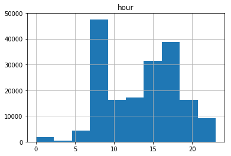

```python
#Exploring the data

df["hour"] = df.start_time.dt.hour
df.hist("hour")
```

## 1. Which are the most popular pick up and drop off stations?

```python
# Popular pickup stations
sfo = folium.Map( location = [37.77, -122.41], zoom_start = 12.5)
for lat,long, startstation, count in zip (startstationdf["start_station_latitude"],startstationdf["start_station_longitude"],
                                          startstationdf["start_station_name"],startstationdf["count"]):folium.CircleMarker([lat, long],
                                        fill_color = "blue",fill_opacity= 0.5,line_color = "blue",radius = 0.0030 * count,
                                        popup = startstation + ": " + str(count) + " rides", tooltip =startstation + ": " + str(count) + " rides").add_to(sfo)
title_html = '''
             <h3 align="center" style="font-size:20px"><b>Popular pick-up stations</b></h3>
             '''
sfo.get_root().html.add_child(folium.Element(title_html))
sfo
```

Make this Notebook Trusted to load map: File -> Trust Notebook

[interactive chart not shown]

```python
sfoend = folium.Map( location = [37.77, -122.41], zoom_start = 12.5)
for lat,long, endstation, count in zip (endstationdf["end_station_latitude"],endstationdf["end_station_longitude"],
                                          endstationdf["end_station_name"],endstationdf["count"]):folium.CircleMarker([lat, long],
                                        fill_color = "blue",fill_opacity= 0.5,line_color = "blue",
                                        radius = 0.0030 * count,line_opacity = 0.5,alpha=0.5,
                                        popup = endstation + ": " + str(count) + " rides",
                                        tooltip = endstation + ": " + str(count) + " rides").add_to(sfoend)
title_html = '''
             <h3 align="center" style="font-size:20px"><b>Popular drop-off stations</b></h3>
             '''
sfoend.get_root().html.add_child(folium.Element(title_html))
sfoend
```

Make this Notebook Trusted to load map: File -> Trust Notebook

[interactive chart not shown]

1.a Market Street at 10th St., San Francisco caltrain station2, Berry Street at 4th Street are few of the most popular pick up stations in San Francisco, where the bikes picked up are more than 3000 per month. These stations are located in the heart of the city and they are well connected to other parts of the city through trains,buses or freeways.

San Francisco Caltrain station2, Market Street at 10th St., Montgomery Street BART Station are few of the most popular drop-off stations in San Francisco with drop off more than 3500 per month. These stations are located in the heart of the city and they are well connected to other parts of the city through trains,buses or freeways.

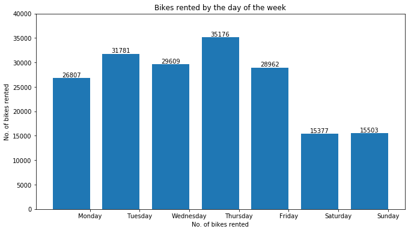

```python
x = weekday_bar['start_weekday']
y = weekday_bar['count']
fig, ax = plt.subplots(figsize=(11,6))
width = 0.75 # the width of the bars
ind = np.arange(len(x))  # the x locations for the groups
ax.bar(ind, y, width)
ax.set_xticks(ind+width/2)
ax.set_xticklabels(x, minor=False)
plt.xlabel('No. of bikes rented')
plt.ylabel('No. of bikes rented')
plt.title('Bikes rented by the day of the week')
plt.ylim([0,40000])
for i in range(len(x)):
    plt.text(i,y[i], y[i], ha= "center", va = "bottom" )
```

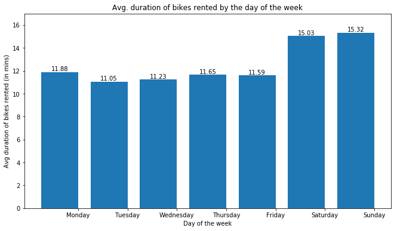

```python
x = weekday_avgmin_df['start_weekday']
y = weekday_avgmin_df['duration_min']
fig, ax = plt.subplots(figsize=(11,6))
width = 0.75 # the width of the bars
ind = np.arange(len(x))  # the x locations for the groups
ax.bar(ind, y, width)
ax.set_xticks(ind+width/2)
ax.set_xticklabels(x, minor=False)
plt.xlabel('Day of the week')
plt.ylabel('Avg duration of bikes rented (in mins)')
plt.title('Avg. duration of bikes rented by the day of the week')
plt.ylim([0,17])
for i in range(len(x)):
    plt.text(i,y[i], y[i], ha= "center", va = "bottom" )
```

2.a The demand for the bikes is highest on Thursday totalling to approximately 35,000 per month.

The bike is rented for higher minutes in weekend as compare to weekdays. On an average bikes are rented for 15 minutes on weekend.